# ExtraaLearn Project

## Context

The EdTech industry has been surging in the past decade immensely, and according to a forecast, the Online Education market would be worth $286.62bn by 2023 with a compound annual growth rate (CAGR) of 10.26% from 2018 to 2023. The modern era of online education has enforced a lot in its growth and expansion beyond any limit. Due to having many dominant features like ease of information sharing, personalized learning experience, transparency of assessment, etc, it is now preferable to traditional education.

In the present scenario due to the Covid-19, the online education sector has witnessed rapid growth and is attracting a lot of new customers. Due to this rapid growth, many new companies have emerged in this industry. With the availability and ease of use of digital marketing resources, companies can reach out to a wider audience with their offerings. The customers who show interest in these offerings are termed as leads. There are various sources of obtaining leads for Edtech companies, like

- The customer interacts with the marketing front on social media or other online platforms.
- The customer browses the website/app and downloads the brochure
- The customer connects through emails for more information.

The company then nurtures these leads and tries to convert them to paid customers. For this, the representative from the organization connects with the lead on call or through email to share further details.

## Objective

ExtraaLearn is an initial stage startup that offers programs on cutting-edge technologies to students and professionals to help them upskill/reskill. With a large number of leads being generated on a regular basis, one of the issues faced by ExtraaLearn is to identify which of the leads are more likely to convert so that they can allocate resources accordingly. You, as a data scientist at ExtraaLearn, have been provided the leads data to:

- Analyze and build an ML model to help identify which leads are more likely to convert to paid customers,
- Find the factors driving the lead conversion process
- Create a profile of the leads which are likely to convert

## Data Description

The data contains the different attributes of leads and their interaction details with ExtraaLearn. The detailed data dictionary is given below.

**Data Dictionary**

- ID: ID of the lead
- age: Age of the lead
- current_occupation: Current occupation of the lead. Values include 'Professional','Unemployed',and 'Student'
- first_interaction: How did the lead first interacted with ExtraaLearn. Values include 'Website', 'Mobile App'
- profile_completed: What percentage of profile has been filled by the lead on the website/mobile app. Values include Low - (0-50%), Medium - (50-75%), High (75-100%)
- website_visits: How many times has a lead visited the website
- time_spent_on_website: Total time spent on the website
- page_views_per_visit: Average number of pages on the website viewed during the visits.
- last_activity: Last interaction between the lead and ExtraaLearn.
  - Email Activity: Seeking for details about program through email, Representative shared information with lead like brochure of program , etc
  - Phone Activity: Had a Phone Conversation with representative, Had conversation over SMS with representative, etc
  - Website Activity: Interacted on live chat with representative, Updated profile on website, etc
- print_media_type1: Flag indicating whether the lead had seen the ad of ExtraaLearn in the Newspaper.
- print_media_type2: Flag indicating whether the lead had seen the ad of ExtraaLearn in the Magazine.
- digital_media: Flag indicating whether the lead had seen the ad of ExtraaLearn on the digital platforms.
- educational_channels: Flag indicating whether the lead had heard about ExtraaLearn in the education channels like online forums, discussion threads, educational websites, etc.
- referral: Flag indicating whether the lead had heard about ExtraaLearn through reference.
- status: Flag indicating whether the lead was converted to a paid customer or not.

## Importing necessary libraries and data

```python
#Libraries to help with reading and manipulating data
import numpy as np
import pandas as pd
#Libraries to help with data visualization
import matplotlib.pyplot as plt
import seaborn as sns

# Code to ignore warnings from function usage
import warnings
warnings.filterwarnings("ignore")

# Removes the limit for the number of displayed columns
pd.set_option("display.max_columns", None)

# Sets the limit for the number of displayed rows
pd.set_option("display.max_rows", 200)

# Importing the Machine Learning models we require from Scikit-Learn
from sklearn.linear_model import LogisticRegression
from sklearn.svm import SVC
from sklearn.tree import DecisionTreeClassifier
from sklearn import tree
from sklearn.ensemble import RandomForestClassifier

# For tuning the model
from sklearn.model_selection import train_test_split, GridSearchCV

# To encode categorical variables
from sklearn.preprocessing import MinMaxScaler, LabelEncoder, OneHotEncoder
from sklearn.impute import SimpleImputer

# To get diferent metric scores
from sklearn import metrics
from sklearn.metrics import confusion_matrix,classification_report,roc_auc_score,precision_recall_curve,roc_curve,make_scorer,recall_score
```

```python
from google.colab import drive
drive.mount('/content/drive')
```

```python
data=pd.read_csv("/content/drive/MyDrive/Colab Notebooks/Project_2/Data/ExtraaLearn.csv")
# Copying data to another variable to avoid any changes to original data
same_data = data.copy()
```

## Data Overview

- Observations
- Sanity checks

```python
data.head()
```

|  | ID | age | current_occupation | first_interaction | profile_completed | website_visits | time_spent_on_website | page_views_per_visit | last_activity | print_media_type1 | print_media_type2 | digital_media | educational_channels | referral | status |
| --- | --- | --- | --- | --- | --- | --- | --- | --- | --- | --- | --- | --- | --- | --- | --- |
| 0 | EXT001 | 57 | Unemployed | Website | High | 7 | 1639 | 1.861 | Website Activity | Yes | No | Yes | No | No | 1 |
| 1 | EXT002 | 56 | Professional | Mobile App | Medium | 2 | 83 | 0.320 | Website Activity | No | No | No | Yes | No | 0 |
| 2 | EXT003 | 52 | Professional | Website | Medium | 3 | 330 | 0.074 | Website Activity | No | No | Yes | No | No | 0 |
| 3 | EXT004 | 53 | Unemployed | Website | High | 4 | 464 | 2.057 | Website Activity | No | No | No | No | No | 1 |
| 4 | EXT005 | 23 | Student | Website | High | 4 | 600 | 16.914 | Email Activity | No | No | No | No | No | 0 |

```python
data.info()
```

```
<class 'pandas.core.frame.DataFrame'>
RangeIndex: 4612 entries, 0 to 4611
Data columns (total 15 columns):
 #   Column                 Non-Null Count  Dtype
---  ------                 --------------  -----
 0   ID                     4612 non-null   object
 1   age                    4612 non-null   int64
 2   current_occupation     4612 non-null   object
 3   first_interaction      4612 non-null   object
 4   profile_completed      4612 non-null   object
 5   website_visits         4612 non-null   int64
 6   time_spent_on_website  4612 non-null   int64
 7   page_views_per_visit   4612 non-null   float64
 8   last_activity          4612 non-null   object
 9   print_media_type1      4612 non-null   object
 10  print_media_type2      4612 non-null   object
 11  digital_media          4612 non-null   object
 12  educational_channels   4612 non-null   object
 13  referral               4612 non-null   object
 14  status                 4612 non-null   int64
dtypes: float64(1), int64(4), object(10)
memory usage: 540.6+ KB
```

**Observations:**

- There are 4612 observations and 15 columns in the dataset.
- All the columns have 4612 non-null values, i.e., there are no missing values in the data.

```python
# Checking unique values in each column
data.nunique()
```

```
ID                       4612
age                        46
current_occupation          3
first_interaction           2
profile_completed           3
website_visits             27
time_spent_on_website    1623
page_views_per_visit     2414
last_activity               3
print_media_type1           2
print_media_type2           2
digital_media               2
educational_channels        2
referral                    2
status                      2
dtype: int64
```

**Observations:**

- ID is a unique identifier for each lead and we can drop this column as it would not add any value to our analysis.
- On the basis of number of unique values in each column and the data description, we can identify the continuous and categorical columns in the data.Whereby; age, time_spent_on website, page_views_per_visit and website_visits are continous columns while all the rest are categorical columns.

```python
# Dropping the columns
data=data.drop(['ID'],axis=1)
```

```python
# Creating numerical columns
num_cols=['age','website_visits','time_spent_on_website','page_views_per_visit']

# Creating categorical variables
cat_cols= ['current_occupation','first_interaction','profile_completed','last_activity','print_media_type1','print_media_type2',
           'digital_media','educational_channels','referral','status']
```

## Exploratory Data Analysis (EDA)

- EDA is an important part of any project involving data.
- It is important to investigate and understand the data better before building a model with it.
- A few questions have been mentioned below which will help you approach the analysis in the right manner and generate insights from the data.
- A thorough analysis of the data, in addition to the questions mentioned below, should be done.

**Questions**

1. Leads will have different expectations from the outcome of the course and the current occupation may play a key role in getting them to participate in the program. Find out how current occupation affects lead status.
2. The company's first impression on the customer must have an impact. Do the first channels of interaction have an impact on the lead status?
3. The company uses multiple modes to interact with prospects. Which way of interaction works best?
4. The company gets leads from various channels such as print media, digital media, referrals, etc. Which of these channels have the highest lead conversion rate?
5. People browsing the website or mobile application are generally required to create a profile by sharing their personal data before they can access additional information.Does having more details about a prospect increase the chances of conversion?

```python
# Checking summary statistics
data[num_cols].describe().T
```

|  | count | mean | std | min | 25% | 50% | 75% | max |
| --- | --- | --- | --- | --- | --- | --- | --- | --- |
| age | 4612.0 | 46.201214 | 13.161454 | 18.0 | 36.00000 | 51.000 | 57.00000 | 63.000 |
| website_visits | 4612.0 | 3.566782 | 2.829134 | 0.0 | 2.00000 | 3.000 | 5.00000 | 30.000 |
| time_spent_on_website | 4612.0 | 724.011275 | 743.828683 | 0.0 | 148.75000 | 376.000 | 1336.75000 | 2537.000 |
| page_views_per_visit | 4612.0 | 3.026126 | 1.968125 | 0.0 | 2.07775 | 2.792 | 3.75625 | 18.434 |

**Observations:**

- Average lead age is around 46 years. It has a high range, from 18 years to 63, indicating good age diversity in the leads.
- At least 50% of the leads visit the website 3 times. However, there are some extreme values, given that the maximum value is 30 times and a minimum of zero.
- The distribution of time spent on the website varies widely, with 25% of leads spending 149 units, and 75% spending 1337 units. In addition, extremes on maximum and minimum, 2537 units and 0 units respectively. Units can be seconds,minutes or hours.

```python
# Creating histograms
# Defining the hist_box() function
def hist_box(data, col):
    f, (ax_box, ax_hist) = plt.subplots(2, sharex=True, gridspec_kw={'height_ratios': (0.15, 0.85)}, figsize=(12, 6))
    # Adding a graph in each part
    sns.boxplot(data=data, x=col, ax=ax_box, showmeans=True)
    sns.histplot(data=data, x=col, kde=True, ax=ax_hist)
    plt.show()
```

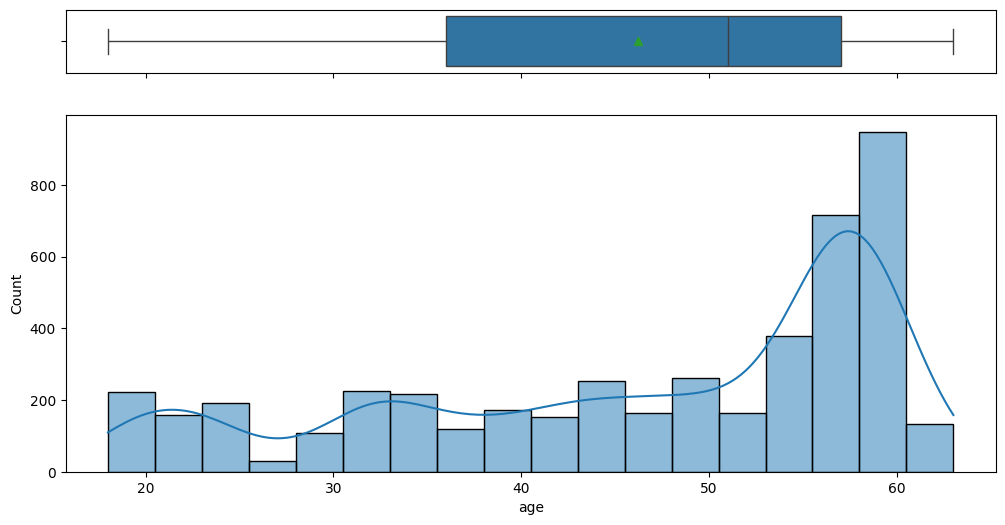

```python
hist_box(data, "age")
```

**Observations**

Age is left skewed with majority of the leads been around 55 to 60. No outliers.

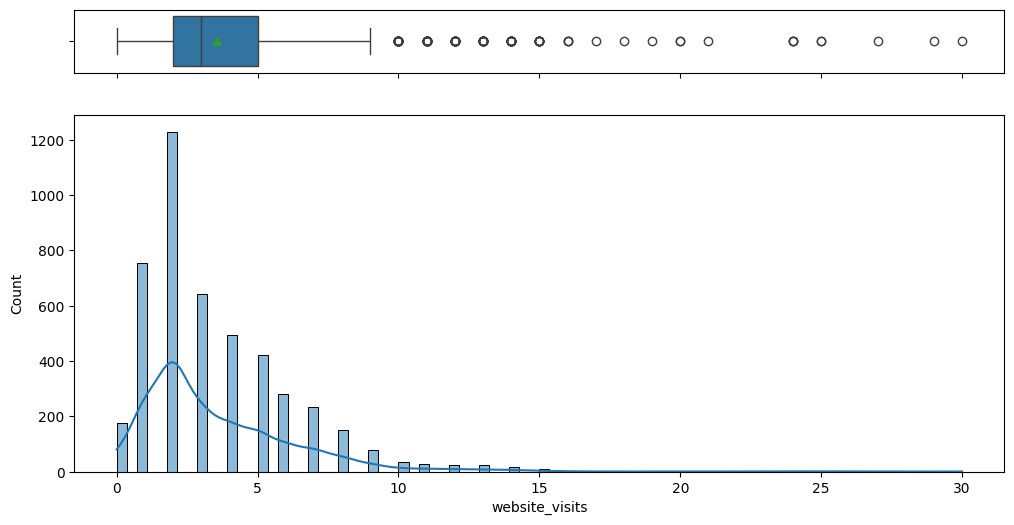

```python
hist_box(data, "website_visits")
```

**Observation:** Website visits skewed to the right. Outliers present from 10 times and above.

```python
#checking how many extreme values are there
data[data['website_visits']>20]
```

|  | age | current_occupation | first_interaction | profile_completed | website_visits | time_spent_on_website | page_views_per_visit | last_activity | print_media_type1 | print_media_type2 | digital_media | educational_channels | referral | status |
| --- | --- | --- | --- | --- | --- | --- | --- | --- | --- | --- | --- | --- | --- | --- |
| 66 | 59 | Unemployed | Mobile App | Medium | 25 | 311 | 2.184 | Phone Activity | No | No | Yes | No | No | 0 |
| 452 | 24 | Student | Mobile App | Low | 24 | 137 | 6.814 | Email Activity | No | No | No | No | No | 0 |
| 509 | 24 | Student | Mobile App | Medium | 30 | 388 | 3.566 | Website Activity | No | No | No | No | No | 0 |
| 1759 | 20 | Student | Website | High | 27 | 417 | 2.071 | Email Activity | No | No | No | No | No | 0 |
| 1933 | 56 | Professional | Website | Medium | 25 | 678 | 3.804 | Email Activity | No | No | No | No | No | 1 |
| 2192 | 40 | Professional | Website | Low | 21 | 216 | 2.252 | Email Activity | No | No | No | No | No | 0 |
| 2694 | 20 | Student | Mobile App | Medium | 29 | 1152 | 3.868 | Phone Activity | No | No | No | Yes | No | 0 |
| 3862 | 58 | Professional | Website | High | 24 | 370 | 2.159 | Phone Activity | No | No | No | No | No | 0 |
| 4583 | 49 | Professional | Website | Medium | 24 | 1039 | 2.064 | Email Activity | Yes | No | No | No | No | 1 |

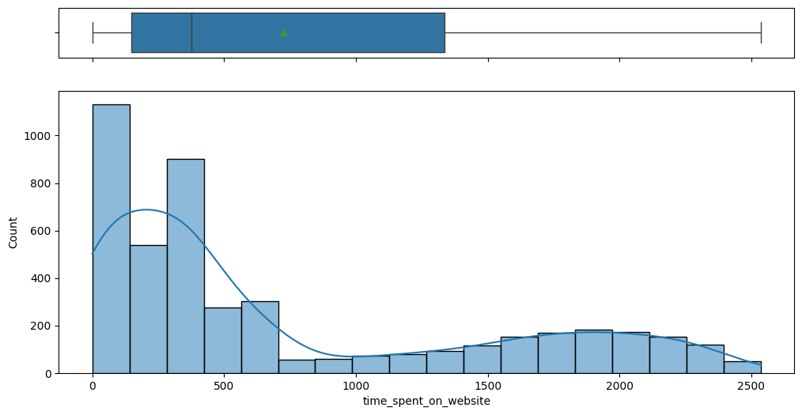

```python
hist_box(data, "time_spent_on_website")
```

**Observations:**

Time spent on website, right skewed. No outliers.

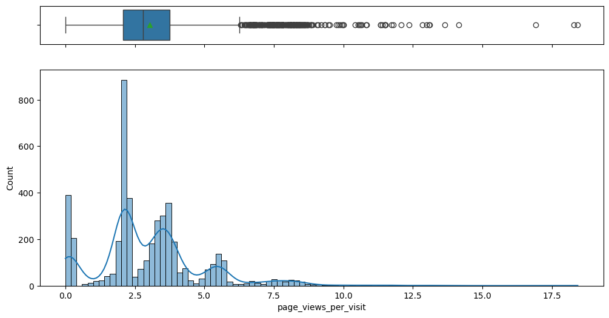

```python
hist_box(data, "page_views_per_visit")
```

**Observation**

Presence of outliers from 6 views and above. High concetration around 2 to 3 views per visit.

```python
#checking how many extreme values are there
data[data['page_views_per_visit']>15]
```

|  | age | current_occupation | first_interaction | profile_completed | website_visits | time_spent_on_website | page_views_per_visit | last_activity | print_media_type1 | print_media_type2 | digital_media | educational_channels | referral | status |
| --- | --- | --- | --- | --- | --- | --- | --- | --- | --- | --- | --- | --- | --- | --- |
| 4 | 23 | Student | Website | High | 4 | 600 | 16.914 | Email Activity | No | No | No | No | No | 0 |
| 32 | 58 | Professional | Mobile App | High | 12 | 1151 | 18.434 | Phone Activity | No | No | No | Yes | No | 0 |
| 268 | 57 | Professional | Mobile App | Medium | 3 | 1009 | 18.302 | Phone Activity | No | No | No | No | No | 0 |

```python
#Univariate Analysis for Categorical Variables
# Printing the % sub categories of each category
for i in cat_cols:
    print(data[i].value_counts(normalize=True))
    print('*'*40)
```

```
Professional    0.567216
Unemployed      0.312446
Student         0.120338
Name: current_occupation, dtype: float64
Website       0.551171
Mobile App    0.448829
Name: first_interaction, dtype: float64
High      0.490893
Medium    0.485906
Low       0.023200
Name: profile_completed, dtype: float64
Email Activity      0.493929
Phone Activity      0.267563
Website Activity    0.238508
Name: last_activity, dtype: float64
No     0.892238
Yes    0.107762
Name: print_media_type1, dtype: float64
No     0.94948
Yes    0.05052
Name: print_media_type2, dtype: float64
No     0.885733
Yes    0.114267
Name: digital_media, dtype: float64
No     0.847138
Yes    0.152862
Name: educational_channels, dtype: float64
No     0.979835
Yes    0.020165
Name: referral, dtype: float64
0    0.701431
1    0.298569
Name: status, dtype: float64
```

**Observations**

- 30% of the leads were converted to paid customers.
- 57% of the leads are professionals, 31% are unemployed and 12% students.
- 55% of the leads used the website as the first interaction with Extraalearn.
- 2% have incomplete profiles and 49% are half-way done.
- 49% of the leads last activity was using the emails as they were seeking for details about program through email, Representative shared information with lead like brochure of program , etc

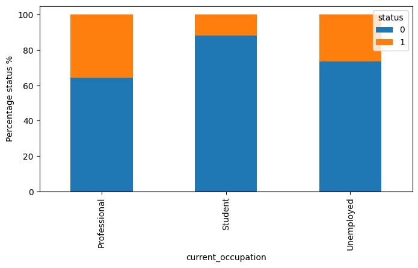

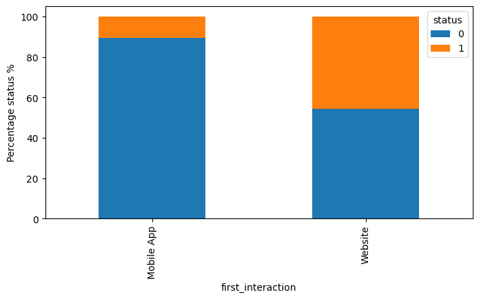

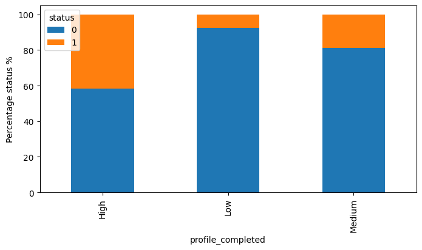

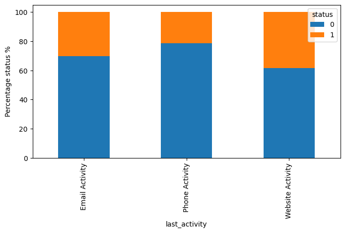

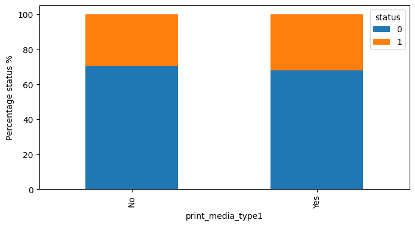

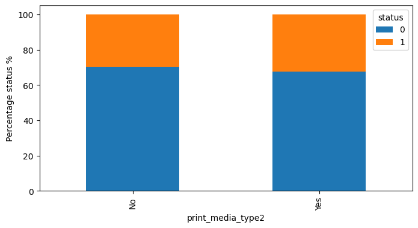

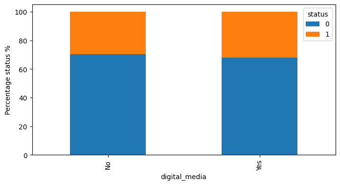

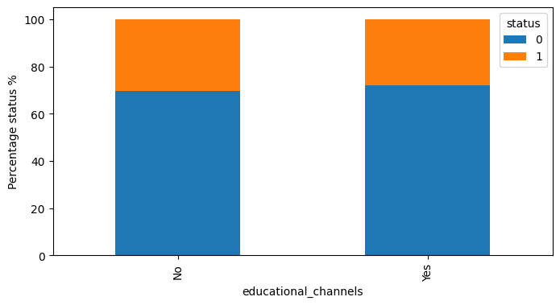

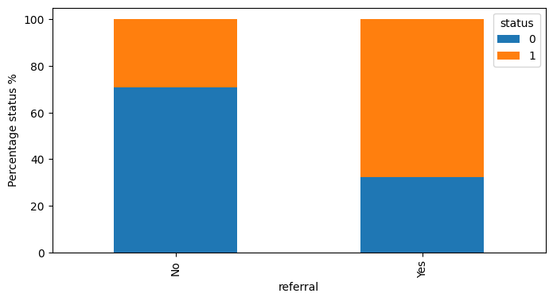

```python
#Bivariate and Multi-variate analysis
for i in cat_cols:
    if i!='status':
        (pd.crosstab(data[i],data['status'],normalize='index')*100).plot(kind='bar',figsize=(8,4),stacked=True)
        plt.ylabel('Percentage status %')
```

**Observations**

- 35% of the professional leads are converted to paid customers. Followed closely by 30% of the unemployed leads are converted to paid customers. That's status 1. The rates could be attrubitable to need to upskill within the job market.
- 45% of the leads who used the Website App as their first interaction with ExtraaLearn are converted to paid customers unlike the Mobile App where the conversion rate is at 10%.
- 40% of the leads who have highly completed their profile are converted to paid customers. If the profile is completed the higher are chances for conversion of leads to paid customers and vice versa.
- 40% of the leads who used the website as their last activity are converted to paid customers.
- 70% of the leads who are referred are converted to paid customers. The rest of the media channels; print media, digital, and educational channels conversion rate is at 30%. Referrals have the highest lead conversion rate.

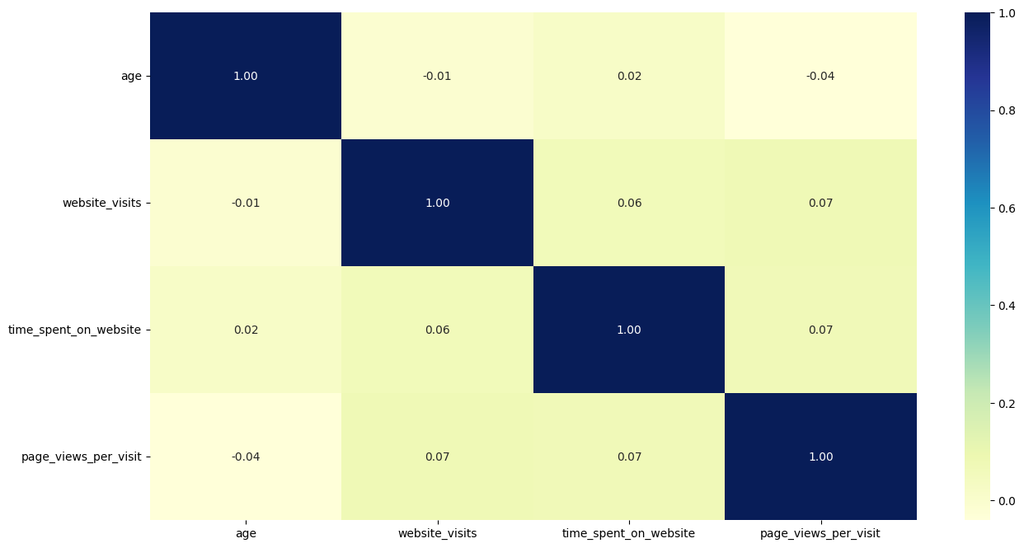

```python
# Plotting the correlation between numerical variables
plt.figure(figsize=(15,8))
sns.heatmap(data[num_cols].corr(),annot=True, fmt='0.2f', cmap='YlGnBu')
```

**Observation**

- No correlation between numerical variables.

## Data Preprocessing

- Missing value treatment (if needed)
- Feature engineering (if needed)
- Outlier detection and treatment (if needed)
- Preparing data for modeling
- Any other preprocessing steps (if needed)

```python
#Outlier Treatment
#Removing outliers from page views and website visits
data.drop(index=data[data.page_views_per_visit>15].index,inplace=True)
data.drop(index=data[data.website_visits>20].index,inplace=True)
```

```python
# Creating list of dummy columns
to_get_dummies_for = ['current_occupation','first_interaction','profile_completed','last_activity' ]

# Creating dummy variables
data = pd.get_dummies(data = data, columns = to_get_dummies_for, drop_first = True)

# Mapping referral, educational channels, digital and print media
dict_referral= {'Yes': 1, 'No':0}
dict_educational_channels = {'Yes': 1, 'No': 0}
dict_digital_media = {'Yes': 1, 'No': 0}
dict_print_media_type1 = {'Yes': 1, 'No': 0}
dict_print_media_type2 = {'Yes': 1, 'No': 0}


data['referral'] = data.referral.map(dict_referral)
data['educational_channels'] = data.educational_channels.map(dict_educational_channels)
data['digital_media'] = data.digital_media.map(dict_digital_media)
data['print_media_type1'] = data.print_media_type1.map(dict_print_media_type1)
data['print_media_type2'] = data.print_media_type2.map(dict_print_media_type2)
```

```python
data.info()
```

```
<class 'pandas.core.frame.DataFrame'>
Int64Index: 4600 entries, 0 to 4611
Data columns (total 17 columns):
 #   Column                          Non-Null Count  Dtype
---  ------                          --------------  -----
 0   age                             4600 non-null   int64
 1   website_visits                  4600 non-null   int64
 2   time_spent_on_website           4600 non-null   int64
 3   page_views_per_visit            4600 non-null   float64
 4   print_media_type1               4600 non-null   int64
 5   print_media_type2               4600 non-null   int64
 6   digital_media                   4600 non-null   int64
 7   educational_channels            4600 non-null   int64
 8   referral                        4600 non-null   int64
 9   status                          4600 non-null   int64
 10  current_occupation_Student      4600 non-null   uint8
 11  current_occupation_Unemployed   4600 non-null   uint8
 12  first_interaction_Website       4600 non-null   uint8
 13  profile_completed_Low           4600 non-null   uint8
 14  profile_completed_Medium        4600 non-null   uint8
 15  last_activity_Phone Activity    4600 non-null   uint8
 16  last_activity_Website Activity  4600 non-null   uint8
dtypes: float64(1), int64(9), uint8(7)
memory usage: 426.8 KB
```

```python
data.describe().T
```

|  | count | mean | std | min | 25% | 50% | 75% | max |
| --- | --- | --- | --- | --- | --- | --- | --- | --- |
| age | 4600.0 | 46.215652 | 13.148888 | 18.0 | 36.000 | 51.000 | 57.00000 | 63.000 |
| website_visits | 4600.0 | 3.522174 | 2.656526 | 0.0 | 2.000 | 3.000 | 5.00000 | 20.000 |
| time_spent_on_website | 4600.0 | 724.276522 | 744.554738 | 0.0 | 148.000 | 376.000 | 1341.25000 | 2537.000 |
| page_views_per_visit | 4600.0 | 3.016100 | 1.932591 | 0.0 | 2.077 | 2.791 | 3.75525 | 14.147 |
| print_media_type1 | 4600.0 | 0.107826 | 0.310194 | 0.0 | 0.000 | 0.000 | 0.00000 | 1.000 |
| print_media_type2 | 4600.0 | 0.050652 | 0.219310 | 0.0 | 0.000 | 0.000 | 0.00000 | 1.000 |
| digital_media | 4600.0 | 0.114348 | 0.318268 | 0.0 | 0.000 | 0.000 | 0.00000 | 1.000 |
| educational_channels | 4600.0 | 0.152826 | 0.359859 | 0.0 | 0.000 | 0.000 | 0.00000 | 1.000 |
| referral | 4600.0 | 0.020217 | 0.140759 | 0.0 | 0.000 | 0.000 | 0.00000 | 1.000 |
| status | 4600.0 | 0.298913 | 0.457831 | 0.0 | 0.000 | 0.000 | 1.00000 | 1.000 |
| current_occupation_Student | 4600.0 | 0.119565 | 0.324488 | 0.0 | 0.000 | 0.000 | 0.00000 | 1.000 |
| current_occupation_Unemployed | 4600.0 | 0.313043 | 0.463782 | 0.0 | 0.000 | 0.000 | 1.00000 | 1.000 |
| first_interaction_Website | 4600.0 | 0.551304 | 0.497415 | 0.0 | 0.000 | 1.000 | 1.00000 | 1.000 |
| profile_completed_Low | 4600.0 | 0.022826 | 0.149365 | 0.0 | 0.000 | 0.000 | 0.00000 | 1.000 |
| profile_completed_Medium | 4600.0 | 0.485870 | 0.499855 | 0.0 | 0.000 | 0.000 | 1.00000 | 1.000 |
| last_activity_Phone Activity | 4600.0 | 0.267174 | 0.442532 | 0.0 | 0.000 | 0.000 | 1.00000 | 1.000 |
| last_activity_Website Activity | 4600.0 | 0.238913 | 0.426466 | 0.0 | 0.000 | 0.000 | 0.00000 | 1.000 |

```python
# Separating target variable and other variables

Y= data.status
X= data.drop(columns = ['status'])
```

```python
# Splitting the data
X_train, X_test, y_train, y_test = train_test_split(X, Y, test_size = 0.3, random_state = 1, stratify = Y)
```

```python
# Scaling the data
# Since we are using Decision Trees and Random Forest,
# does not require feature scaling to be performed as they are not sensitive to the variance in the data. Unlike SVM and Logistic Regression.
```

**Model Evaluation Criterion**

The model can make wrong predictions as:

1. Predicting a lead will convert to paid customer and the lead doesn't convert to paid customer - Loss of resources
2. Predicting a lead will not convert to paid customer and the lead converts to paid customer - Loss of opportunity.

Which case is more important?

Predicting a lead will not convert to paid customer and the lead converts to paid customer i.e. losing on a potential source of income for the company because that lead will not be targeted by the marketing team when he should be targeted.

How to reduce this loss i.e need to reduce False Negatives?

The company wants Recall to be maximized, the greater the Recall lesser the chances of false negatives.

```python
# Creating metric function
def metrics_score(actual, predicted):
    print(classification_report(actual, predicted))

    cm = confusion_matrix(actual, predicted)
    plt.figure(figsize=(8,5))

    sns.heatmap(cm, annot=True,  fmt='.2f', xticklabels=['Not Convert', 'Convert'], yticklabels=['Not Convert', 'Convert'])
    plt.ylabel('Actual')
    plt.xlabel('Predicted')
    plt.show()
```

## Building a Decision Tree model

```python
# Building decision tree model
dt = DecisionTreeClassifier(class_weight = {0: 0.17, 1: 0.83}, random_state = 1)
```

```python
# Fitting decision tree model
dt.fit(X_train, y_train)
```

```
DecisionTreeClassifier(class_weight={0: 0.17, 1: 0.83}, random_state=1)
```

```
              precision    recall  f1-score   support

           0       1.00      1.00      1.00      2258
           1       1.00      1.00      1.00       962

    accuracy                           1.00      3220
   macro avg       1.00      1.00      1.00      3220
weighted avg       1.00      1.00      1.00      3220
```

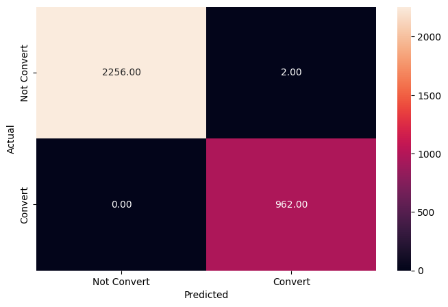

```python
# Checking performance on the training dataset
y_train_pred_dt = dt.predict(X_train)

metrics_score(y_train, y_train_pred_dt)
```

**Observation**

The Decision tree is giving a 100% score for all metrics on the training dataset.

```
              precision    recall  f1-score   support

           0       0.85      0.87      0.86       967
           1       0.68      0.64      0.66       413

    accuracy                           0.80      1380
   macro avg       0.76      0.75      0.76      1380
weighted avg       0.80      0.80      0.80      1380
```

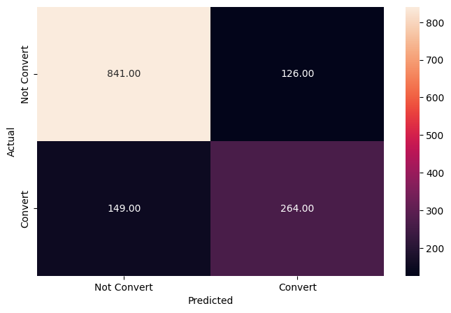

```python
# Checking performance on the test dataset
y_test_pred_dt = dt.predict(X_test)

metrics_score(y_test, y_test_pred_dt)
```

**Observation**

- The Decision Tree works well on the training data but not so well on the test data as the recall is 0.64 in comparison to 1 for the training dataset, i.e., the Decision Tree is overfitting the training data.
- The precision on the test data suggests that there's a 32% (1 - 0.68) chance that the model will predict that a lead is going to convert to paid customer even though he/she would not, and the company may waste their resources in marketing.

## Do we need to prune the tree?

Following, that the decision tree is overfitting whereby the decision tree works best in training dataset while not so well on the test dataset.

Performing pruning by adjusting the hyperparameters for the decision tree model.

```python
# Perform hyperparameter tuning for the decision tree model using GridSearch CV
#Choose the type of classifier.
estimator = DecisionTreeClassifier(random_state=1)

# Grid of parameters to choose from
parameters = {
    "max_depth": np.arange(1,100,10),
    "max_leaf_nodes": [50, 75, 150, 250],
    "min_samples_split": [10, 30, 50, 70],
}
# Run the grid search
grid_obj = GridSearchCV(estimator, parameters, cv=5,scoring='recall',n_jobs=-1)
grid_obj = grid_obj.fit(X_train, y_train)

# Set the clf to the best combination of parameters
estimator = grid_obj.best_estimator_

# Fit the best algorithm to the data.
estimator.fit(X_train, y_train)
```

```
DecisionTreeClassifier(max_depth=11, max_leaf_nodes=50, min_samples_split=70,
                       random_state=1)
```

```
              precision    recall  f1-score   support

           0       0.91      0.92      0.91      2258
           1       0.81      0.77      0.79       962

    accuracy                           0.88      3220
   macro avg       0.86      0.85      0.85      3220
weighted avg       0.88      0.88      0.88      3220
```

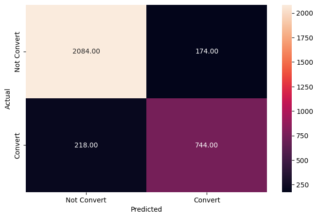

```python
# Checking performance on the training dataset
dt_tuned = estimator.predict(X_train)
metrics_score(y_train,dt_tuned)
```

```
              precision    recall  f1-score   support

           0       0.88      0.91      0.89       967
           1       0.78      0.70      0.73       413

    accuracy                           0.85      1380
   macro avg       0.83      0.81      0.81      1380
weighted avg       0.85      0.85      0.85      1380
```

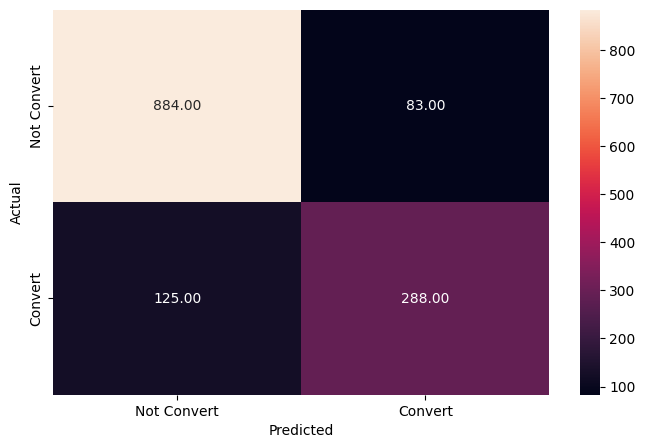

```python
# Checking performance on the test dataset
y_pred_tuned = estimator.predict(X_test)
metrics_score(y_test,y_pred_tuned)
```

**Observation**

After hyper parameters tuning, the recall is 0.70 in comparison to 0.77 for the training dataset.

The precision on the test data suggests that there's a 22% (1 - 0.78) chance that the model will predict that a lead is going to convert to paid customer even though he/she would not, and the company may waste their resources in marketing.

The accuracy of the model is at 85%. Improvement from 80%.

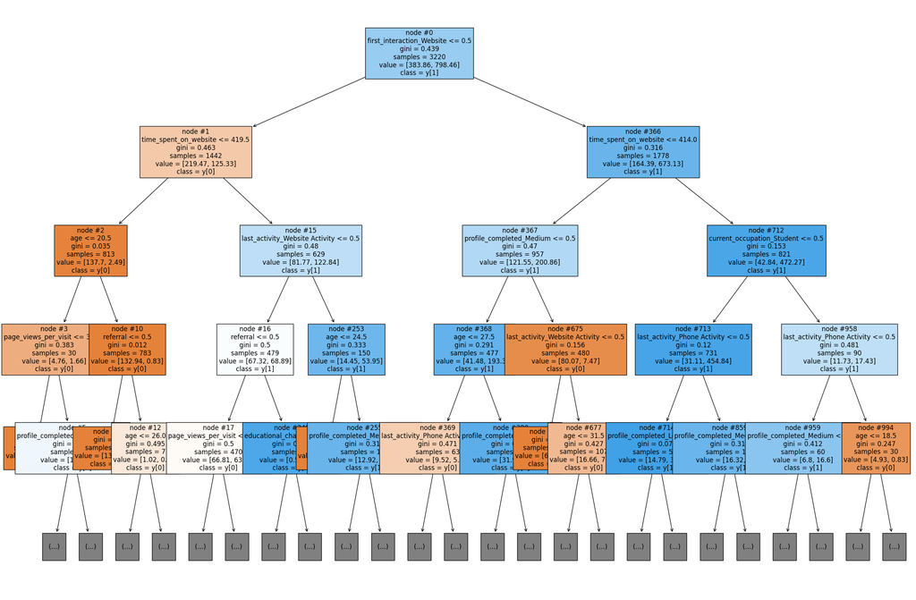

```python
features = list(X.columns)

plt.figure(figsize = (30, 20))

tree.plot_tree(dt, max_depth = 4, feature_names = features, filled = True, fontsize = 12, node_ids = True, class_names = True)

plt.show()
```

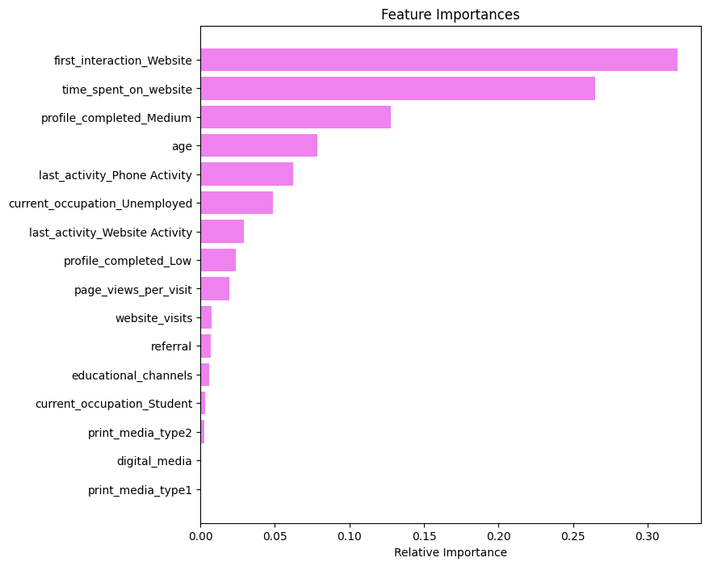

```python
# Importance of features in the tree building
importances = estimator.feature_importances_
indices = np.argsort(importances)

plt.figure(figsize=(8, 8))
plt.title("Feature Importances")
plt.barh(range(len(indices)), importances[indices], color="violet", align="center")
plt.yticks(range(len(indices)), [features[i] for i in indices])
plt.xlabel("Relative Importance")
plt.show()
```

**Observations**

The most important features are:

- First interaction
- Time spent on the website.
- Profile completed

This might signify that leads that convert to paid customers interact first with Extraalearn on the website, have high time spent on the website and have their profile completed.

## Building a Random Forest model

```python
# Fitting the Random Forest classifier on the training data
rf_estimator = RandomForestClassifier(class_weight = {0: 0.17, 1: 0.83}, random_state = 1)

rf_estimator.fit(X_train, y_train)
```

```
RandomForestClassifier(class_weight={0: 0.17, 1: 0.83}, random_state=1)
```

```
              precision    recall  f1-score   support

           0       1.00      1.00      1.00      2258
           1       1.00      1.00      1.00       962

    accuracy                           1.00      3220
   macro avg       1.00      1.00      1.00      3220
weighted avg       1.00      1.00      1.00      3220
```

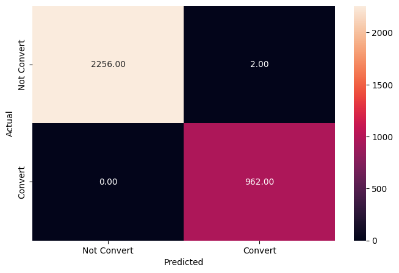

```python
# Checking performance on the training data
y_pred_train_rf = rf_estimator.predict(X_train)

metrics_score(y_train, y_pred_train_rf)
```

```
              precision    recall  f1-score   support

           0       0.86      0.93      0.90       967
           1       0.80      0.65      0.72       413

    accuracy                           0.85      1380
   macro avg       0.83      0.79      0.81      1380
weighted avg       0.84      0.85      0.84      1380
```

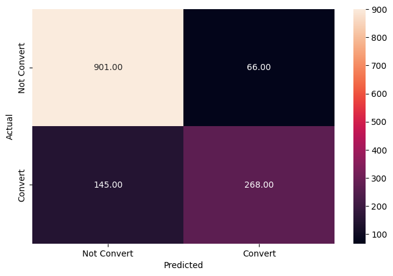

```python
y_pred_test_rf = rf_estimator.predict(X_test)

metrics_score(y_test, y_pred_test_rf)
```

**Observations:**

- The Random Forest classifier seems to be overfitting the training data. The recall on the training data is 1, while the recall on the test data is 0.65.
- We can reduce overfitting and improve recall by hyperparameter tuning,

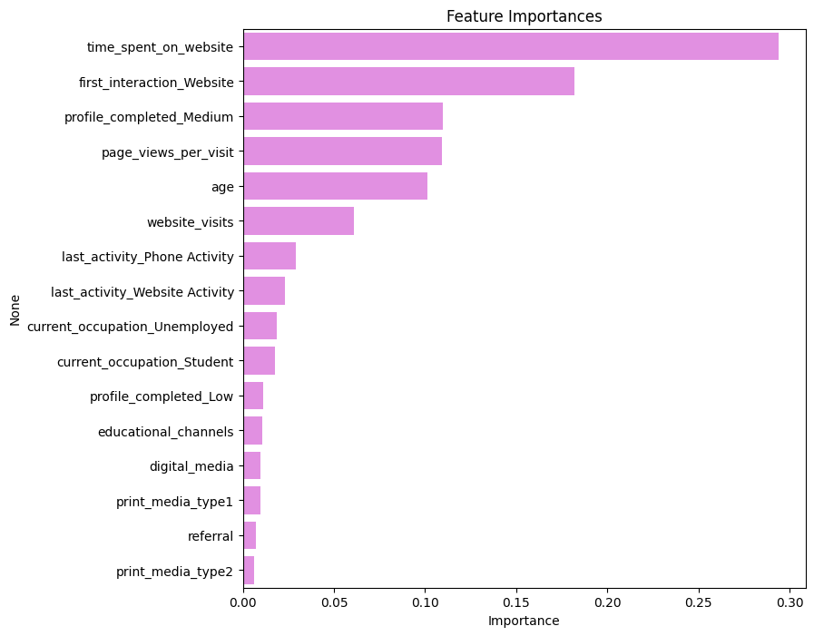

```python
#Feature importance in random forest
importances = rf_estimator.feature_importances_

columns = X_train.columns

importance_data = pd.DataFrame(importances, index = columns, columns = ['Importance']).sort_values(by = 'Importance', ascending = False)


plt.figure(figsize=(8, 8))
plt.title("Feature Importances")
sns.barplot(x = importance_data.Importance, y = importance_data.index, color="violet")
```

## Do we need to prune the tree?

```python
# Choose the type of classifier
rf_estimator_tuned = RandomForestClassifier(class_weight = {0: 0.17, 1: 0.83}, random_state = 1)

# Grid of parameters to choose from
params_rf = {
        "n_estimators": [100, 250, 500],
        "min_samples_leaf": np.arange(1, 4, 1),
        "max_features": [0.7, 0.9, 'auto'],
}


# Type of scoring used to compare parameter combinations - recall score for class 1
scorer = metrics.make_scorer(recall_score, pos_label = 1)

# Run the grid search
grid_obj = GridSearchCV(rf_estimator_tuned, params_rf, scoring = scorer, cv = 5)

grid_obj = grid_obj.fit(X_train, y_train)

# Set the classifier to the best combination of parameters
rf_estimator_tuned = grid_obj.best_estimator_
```

```python
rf_estimator_tuned.fit(X_train, y_train)
```

```
RandomForestClassifier(class_weight={0: 0.17, 1: 0.83}, max_features='auto',
                       min_samples_leaf=3, random_state=1)
```

```
              precision    recall  f1-score   support

           0       0.99      0.89      0.94      2258
           1       0.80      0.99      0.88       962

    accuracy                           0.92      3220
   macro avg       0.90      0.94      0.91      3220
weighted avg       0.94      0.92      0.92      3220
```

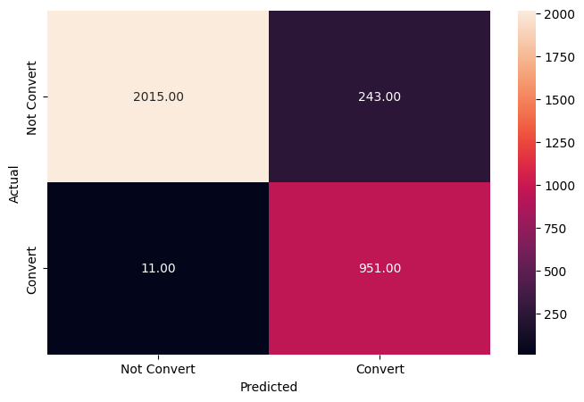

```python
# Checking performance on the training data
y_pred_train_rf_tuned = rf_estimator_tuned.predict(X_train)

metrics_score(y_train, y_pred_train_rf_tuned)
```

```
              precision    recall  f1-score   support

           0       0.91      0.85      0.88       967
           1       0.70      0.81      0.75       413

    accuracy                           0.84      1380
   macro avg       0.81      0.83      0.82      1380
weighted avg       0.85      0.84      0.84      1380
```

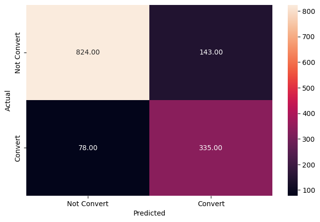

```python
# Checking performance on the test data
y_pred_test_rf_tuned = rf_estimator_tuned.predict(X_test)

metrics_score(y_test, y_pred_test_rf_tuned)
```

**Observations:**

- Random Forest Classifier after hyperparameters tuning is performing the best, with the agenda improving the recall scores of the dataset.
- The recall scores have improved with decrease in precision on the test dataset.

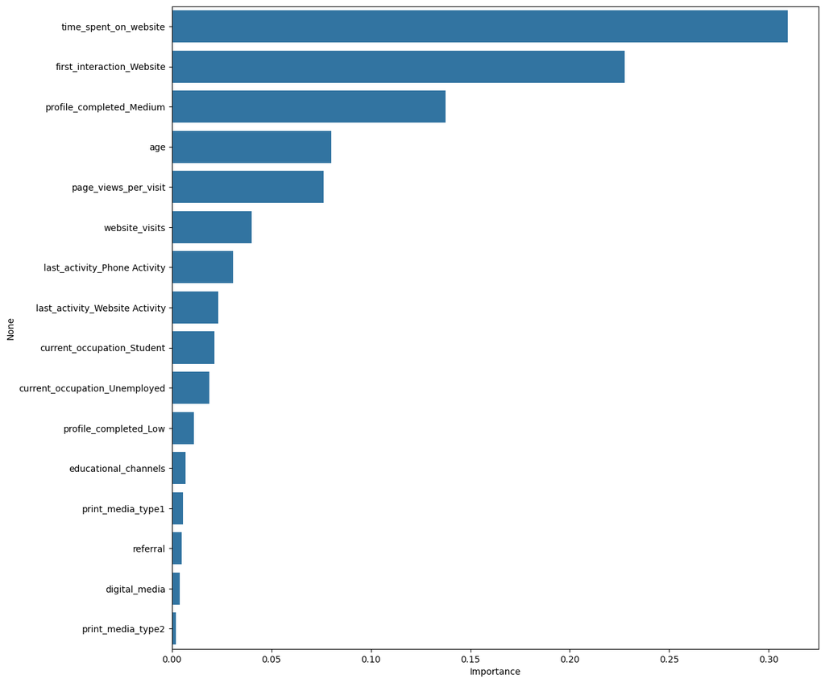

```python
# Plotting feature importance
importances = rf_estimator_tuned.feature_importances_
columns = X.columns
importance_df = pd.DataFrame(importances, index = columns, columns = ['Importance']).sort_values(by = 'Importance', ascending = False)
plt.figure(figsize = (13, 13))
sns.barplot(data = importance_df, x = importance_df.Importance, y = importance_df.index)
```

**Observations:**

- The feature importance plot for the base model and tuned model are quite similar.
- The tuned model highlights that the most important features in determining if a lead is highly likely to convert to paid customers are time spent on the website, first interaction with the website, profile completion, Age, and page views per visit.

## Actionable Insights and Recommendations

**Observations**

The main agenda was to improve the recall scores with the potential customers prediction modelling, i.e., minimizing the error of predicting a lead wouldn't convert to an actual paid customer while in the actual sense they do.

Based on the modelling done, we observed that the key variables that give information are the time spent on the website, first interactivity with the Extraalearn website, profile completion, age and page views per visit:

Actionable Insights:

- We see that there is a high likelihood of a lead been converted to a customer when there's increased time spent on the website.
- Extraalearn should focus on the website as the information on the site gives insights to the lead if to purchase the services offered by ExtraaLearn. Continously revamping the website as well as updating the website with information that can provide additional insights to the lead, bronchures on the site been up to date.
- In addition, profile completion indicates that the lead is interested in purchasing the services offered by Extraalearn.
- Different mediums of advertising used by Extraalearn such as newspaper, digital platform, magazines least likely converts leads to paid customers.